# Plankton Recognition Challenge

Plankton comprises all the organisms freely drifting with ocean currents. These life forms are a critically important piece of oceanic ecosystems, accounting for more than half the primary production on earth and nearly half the total carbon fixed in the global carbon cycle. They also form the foundation of aquatic food webs, including those of large, commercially important fisheries. Loss of plankton populations could result in ecological upheaval as well as negative societal impacts, particularly in indigenous cultures and the developing world. Plankton’s global significance makes their population levels an ideal measure of the health of the world’s oceans and ecosystems.

Traditional methods for measuring and monitoring plankton populations are time consuming and cannot scale to the granularity or scope necessary for large-scale studies. Improved approaches are needed. One such approach is through the use of underwater imagery sensors.

In this challenge, which was prepared in cooperation with the Laboratoire d’Océanographie de Villefranche, jointly run by Sorbonne Université and CNRS, plankton images were acquired in the bay of Villefranche, weekly since 2013 and manually engineered features were computed on each imaged object.

This challenge aims at developing solid approaches to plankton image classification. As an alternative, it is possible to use methods based on carefully (but manually) engineered features. This is in sharp contrast with “Deep Learning” methods in which features will be learned from image data alone.

The purpose of this challenge is for you to learn about the commonly used paradigms when working with real-life problems. This means you can choose one of the following paths:

- Work directly with the provided images, e.g. using a (convolutional) neural network
- Work with the supplied features extracted from the images (*native* or *skimage* or both of them)
- Extract your own features from the provided images using a technique of your choice

You will find a detailed description about the image data and the features at the end of this text. In any case, the choice of the classifier that you decide to work with strongly depends on the choice of features.

Please bear in mind that the purpose of this challenge is not to find the best-performing model (e.g. on Kaggle there are competitions to do just that, with similar data as for this challenge). You should rather make sure to understand the dificulties that come with computer vision task, should you take this modeling approach. Moreover, you should be able to justify your choice of features/model and be able to explain its advantages and disadvantages for the task.

**IMPORTANT**: please refer to the AML course guidelines concerning grading rules. Pay especially attention to the **presentation quality** item, which boils down to: don't dump a zillion of lines of code and plots in this notebook. Produce a concise summary of your findings: this notebook can exist in two versions, a "scratch" version that you will use to work and debug, a "presentation" version that you will submit. The "presentation" notebook should go to the point, and convay the main findings of your work.

## Overview

Beyond simply producing a well-performing model for making predictions, in this challenge we would like you to start developing your skills as a machine learning scientist. In this regard, your notebook should be structured in such a way as to explore the following tasks that are expected to be carried out whenever undertaking such a project. The description below each aspect should serve as a guide for your work, but you are strongly encouraged to also explore alternative options and directions. Thinking outside the box will always be rewarded in these challenges.

### 1. Data preparation:

*Data exploration*: The first broad component of your work should enable you to familiarise yourselves with the given data, an outline of which is given at the end of this challenge specification. Among others, you can work on:

- Data cleaning, e.g. treatment of categorial variables;
- Data visualisation; Computing descriptive statistics, e.g. correlation.

What is new in this challenge is that you will be working with image data. Therefore, you should have a look at example images located in the *imgs.zip* file (see description below). If you decide to work with the native or the skimage features, make sure to understand them!

Among others, this section should investigate:

- Distribution of the different image dimensions (including the number of channels)
- Distribution of the different labels that the images are assigned to

The image labels are organized in a taxonomy. We will measure the final model performance for the classification into the *level2* categories. Make sure to understand the meaning of this label inside the taxonomy.

*Data Pre-processing*: The previous step should give you a better understanding of which pre-processing is required for the data. This may include:

- Normalising and standardising the given data;
- Removing outliers;
- Carrying out feature selection, possibly using metrics derived from information theory;
- Handling missing information in the dataset;
- Augmenting the dataset with external information;
- Combining existing features.

Please take also note of the following aspects, that are related to this particular challente:

- If you decide to work with the provided features, some data cleaning may be required to make full use of all the data.
- If you decide to extract your own features from the images, you should explain your approach in this section.
- If you decide to work directly with the images themselves, preprocessing the images may improve your classification results. In particular, if you work with a neural network the following should be of interest to you:
  - Due to the fully-connected layers (that usually come after the convolutional ones), the input needs to have a fixed dimension.
  - Data augmentation (image rotation, scaling, cropping, etc. of the existing images) can be used to increase the size of the training data set. This may improve performance especially when little data is available for a particular class.
  - Be aware of the computational cost! It might be worth rescaling the images to a smaller size!

  All of the operations above are usually realized using a dataloader. This means that you do not need to create a modified version of the dataset and save it to disk. Instead, the dataloader processes the data "on the fly" and in-memory before passing it to the network.

  NB: Although aligning image sizes is necessary to train CNNs, this will prevent your classifier from learning about different object sizes as a feature. Additional gains may be achieved when also taking object sizes into account.

### 2. Model selection

An important part of the work involves the selection of a model that can successfully handle the given data and yield sensible predictions. Instead of focusing exclusively on your final chosen model, it is also important to share your thought process in this notebook by additionally describing alternative candidate models. There is a wealth of models to choose from, such as decision trees, random forests, (Bayesian) neural networks, Gaussian processes, LASSO regression, and so on.

Irrespective of your choice, it is highly likely that your model will have one or more parameters that require tuning. There are several techniques for carrying out such a procedure, such as cross-validation.

### 3. Performance Evaluation

For the evaluation of the classification results in this challenge, you should use the F1 measure. Here the focus should be on level2 classification.

You should indicate your final evaluation score on a held-out test set. As an evaluation metric you should use the F1 score with the *average=macro* option as it is provided by the scikit-learn library. See the following link for more information:

https://scikit-learn.org/stable/modules/generated/sklearn.metrics.f1_score.html

Please note that you are responsible for creating a sensible train/validation/test split. There is no predefined held-out test data.

## Dataset Description

#### * Location of the Dataset on the cloud platform

The data for this challenge is located at: `/mnt/datasets/plankton/flowcam`

#### * Hierachical Taxonomy Tree for Labels

Each object is represented by a single image and is identified by a unique integer number. It has a name associated to it which is integrated in a hierarchical taxonomic tree. The identifications are gathered from different projects, classified by different people in different contexts, so they often target different taxonomic levels. For example, let us say we classify items of clothing along the following tree

```
top
    shirt
        long sleeves
        short sleeves
    sweater
        hooded
        no hood
bottom
    pants
        jeans
        other
    shorts
```

In a first project, images are classified to the finest level possible, but it may be the case that, on some pictures, it is impossible to determine whether a sweater has a hood or not, in which case it is simply classified as `sweater`. In the second project, the operator classified tops as `shirt` or `sweater` only, and bottoms to the finest level. In a third project, the operator only separated tops from bottoms. In such a context, the original names in the database cannot be used directly because, for example `sweater` will contain images that are impossible to determine as `hooded` or `no hood` *as well as* `hooded` and `no hood` images that were simply not classified further. If all three classes (`sweater`, `hooded`, and `no hood`) are included in the training set, it will likely confuse the classifier. For this reason, we define different target taxonomic levels:

- `level1` is the finest taxonomic level possible. In the example above, we would include `hooded` and `no hood` but discard all images in `sweater` to avoid confusion; and proceed in the same manner for other classes.
- `level2` is a grouping of underlying levels. In the example above, it would include `shirt` (which contains all images in `shirt`, `long sleeves`, and `short sleeves`), `sweater` (which, similarly would include this class and all its children), `pants` (including children), and `shorts`. So typically, `level2` contains more images (less discarding), sorted within fewer classes than `level1`, and may therefore be an easier classification problem.
- `level3` is an even broader grouping. Here it would be `top` vs `bottom`
- etc.

In the Plankton Image dataset, the objects will be categorised based on a pre-defined 'level1' and 'level2'. You can opt to work on one of them, but we recommend you to work on `level2` because it is an easier classification problem.

#### * Data Structure

```
/mnt/datasets/plankton/flowcam/
    meta.csv
    taxo.csv
    features_native.csv.gz
    features_skimage.csv.gz
    imgs.zip
```

- `meta.csv` contains the index of images and their corresponding labels
- `taxo.csv` defines the taxonomic tree and its potential groupings at various level. Note that, the information is also available in `meta.csv`. Therefore, the information in `taxo.csv` is probably useless, but at least it gives you a global view about taxonomy tree
- `features_native.csv.gz` contain the morphological handcrafted features computed by ZooProcess. In fact, ZooProcess generates the region of interests (ROI) around each individual object from a original image of Plankton. In addition, it also computes a set of associated features measured on the object. These features are the ones contained in `features_native.csv.gz`
- `features_skimage.csv.gz` contains the morphological features recomputed with skimage.measure.regionprops on the ROIs produced by ZooProcess.
- `imgs.zip` contains a post-processed version of the original images. Images are named by `objid`.jpg

#### * Attributes in meta.csv

The file contains the image identifiers (objid) as well as the labels assigned to the images by human operators. Those are defined with various levels of precision:

- *unique_name*: raw labels from operators
- *level1*: cleaned, most detailed labels
- *level2*: regrouped (coarser) labels
- *lineage*: full taxonomic lineage of the class

Some labels may be missing (coded ‘NA’) at a given level, meaning that the corresponding objects should be discarded for the classification at this level.

#### * imgs.zip

This zip archive contains an *imgs* folder that contains all the images in .jpg format. Do not extract this folder to disk! Instead you will be loading the images to memory. See the code below for a quick how-to:

#### * Attributes in features_native.csv.gz

A brief outline of the availabel attributes in `features_native.csv.gz` which you can use is given below:

- *objid*: same as in `meta.csv`
- *area*: area of ROI
- *meanimagegrey*:
- *mean*: mean grey
- *stddev*: standard deviation of greys
- *min*: minimum grey
- *perim.*: perimeter of ROI
- *width, height*: dimensions of ROI
- *major, minor*: length of major,minor axis of the best fitting ellipse
- *angle*:
- *circ.*: circularity or shape factor which can be computed by 4pi(area/perim.^2)
- *feret*: maximal feret diameter
- *intden*: integrated density: mean*area
- *median*: median grey
- *skew, kurt*: skewness,kurtosis of the histogram of greys
- *%area*: proportion of the image corresponding to the object
- *area_exc*: area excluding holes
- *fractal*: fractal dimension of the perimeter
- *skelarea*: area of the one-pixel wide skeleton of the image ???
- *slope*: slope of the cumulated histogram of greys
- *histcum1, 2, 3*: grey level at quantiles 0.25, 0.5, 0.75 of the histogram of greys
- *nb1, 2, 3*: number of objects after thresholding at the grey levels above
- *symetrieh, symetriev*: index of horizontal,vertical symmetry
- *symetriehc, symetrievc*: same but after thresholding at level histcum1
- *convperim, convarea*: perimeter,area of the convex hull of the object
- *fcons*: contrast
- *thickr*: thickness ratio: maximum thickness/mean thickness
- *esd*:
- *elongation*: elongation index: major/minor
- *range*: range of greys: max-min
- *meanpos*: relative position of the mean grey: (max-mean)/range
- *centroids*:
- *cv*: coefficient of variation of greys: 100*(stddev/mean)
- *sr*: index of variation of greys: 100*(stddev/range)
- *perimareaexc*:
- *feretareaexc*:
- *perimferet*: index of the relative complexity of the perimeter: perim/feret
- *perimmajor*: index of the relative complexity of the perimeter: perim/major
- *circex*:
- *cdexc*:
- *kurt_mean*:
- *skew_mean*:
- *convperim_perim*:
- *convarea_area*:
- *symetrieh_area*:
- *symetriev_area*:
- *nb1_area*:
- *nb2_area*:
- *nb3_area*:
- *nb1_range*:
- *nb2_range*:
- *nb3_range*:
- *median_mean*:
- *median_mean_range*:
- *skeleton_area*:

#### * Attributes in features_skimage.csv.gz

Table of morphological features recomputed with skimage.measure.regionprops on the ROIs produced by ZooProcess. See http://scikit-image.org/docs/dev/api/skimage.measure.html#skimage.measure.regionprops for documentation.

```python
import numpy as np
import seaborn as sns
import matplotlib.pyplot as plt
import pandas as pd

from collections import Counter

from sklearn.model_selection import train_test_split, GridSearchCV
from sklearn import preprocessing
from sklearn.metrics import f1_score
from skimage.transform import resize
from sklearn.preprocessing import PowerTransformer

from tensorflow.keras.models import Sequential
from tensorflow.keras.layers import Dense, Conv2D, Flatten, Lambda, Reshape, MaxPooling2D
from tensorflow.keras.utils import Sequence, to_categorical

import zipfile
from io import BytesIO
from PIL import Image
import time
import sklearn
from sklearn.linear_model import LogisticRegression
from sklearn.ensemble import RandomForestClassifier
from sklearn.ensemble import GradientBoostingClassifier
from sklearn.model_selection import cross_val_score
from sklearn.model_selection import cross_validate
from sklearn.model_selection import GridSearchCV
from sklearn.preprocessing import OneHotEncoder, OrdinalEncoder
from sklearn.metrics import confusion_matrix, accuracy_score
```

```python
features_native = pd.read_csv("features_native.csv")
meta = pd.read_csv("meta.csv")
```

```python
nan_count = features_native.isna().sum()
print("NaN values count")
print(nan_count[nan_count.index[np.array(nan_count).nonzero()]])
```

```
NaN values count
perimareaexc      34428
feretareaexc      34428
cdexc             34428
convarea_area      6854
symetrieh_area     6854
symetriev_area     6854
nb1_area           6854
nb2_area           6854
nb3_area           6854
skeleton_area      6854
dtype: int64
```

```python
data = features_native
data.loc[:, "level2"] = meta.loc[:, "level2"]
data_clean = data.dropna(subset=['level2'])


L = ["perimareaexc","feretareaexc","cdexc","convarea_area","symetrieh_area",
     "symetriev_area","nb1_area","nb2_area","nb3_area","skeleton_area"]

for machin in L:
    data_clean[machin] = data_clean[machin].fillna((data_clean[machin].mean()))

classes = data_clean['level2'].unique()
num_classes = len(classes)
classes_ids = {k: v for v, k in enumerate(classes)}
print(classes_ids)
print("Number of classes: "+str(num_classes))


encoder = OrdinalEncoder()
encoder.fit(data_clean)
data_clean.loc[:, "level2"] = encoder.transform(data_clean)[:,-1]
```

```python
nan_count = data_clean.isna().sum()
print("NaN values count")
print(nan_count[nan_count.index[np.array(nan_count).nonzero()]])
```

```
NaN values count
Series([], dtype: int64)
```

```python
data_clean
```

|  | objid | area | meanimagegrey | mean | stddev | min | perim. | width | height | major | ... | nb1_area | nb2_area | nb3_area | nb1_range | nb2_range | nb3_range | median_mean | median_mean_range | skeleton_area | level2 |
| --- | --- | --- | --- | --- | --- | --- | --- | --- | --- | --- | --- | --- | --- | --- | --- | --- | --- | --- | --- | --- | --- |
| 0 | 32756761.0 | 6653.0 | 167.18 | 205.76 | 65.341 | 85 | 779.66 | 109 | 123 | 147.8 | ... | 0.017964 | 0.017964 | 0.059880 | 0.017647 | 0.017647 | 0.058824 | 47 | 0.276471 | 91.778443 | 30.0 |
| 1 | 32759364.0 | 1275.0 | 165.83 | 234.29 | 38.562 | 98 | 186.99 | 33 | 65 | 82.4 | ... | 0.024096 | 0.012048 | 0.006024 | 0.025478 | 0.012739 | 0.006369 | 21 | 0.133758 | 18.030120 | 30.0 |
| 2 | 32758055.0 | 2416.0 | 167.92 | 239.15 | 25.590 | 94 | 276.33 | 26 | 115 | 138.8 | ... | 0.011905 | 0.053571 | 0.107143 | 0.012422 | 0.055901 | 0.111801 | 16 | 0.099379 | 24.892857 | 20.0 |
| 3 | 32758988.0 | 1433.0 | 167.34 | 248.79 | 20.933 | 107 | 388.40 | 126 | 117 | 151.2 | ... | 0.000000 | 0.000000 | 0.023952 | 0.000000 | 0.000000 | 0.027027 | 6 | 0.040541 | 99.365269 | 37.0 |
| 4 | 32760598.0 | 1650.0 | 166.89 | 250.42 | 14.603 | 124 | 751.96 | 66 | 239 | 278.7 | ... | 0.029940 | 0.083832 | 0.059880 | 0.038168 | 0.106870 | 0.076336 | 5 | 0.038168 | 109.449102 | 37.0 |
| ... | ... | ... | ... | ... | ... | ... | ... | ... | ... | ... | ... | ... | ... | ... | ... | ... | ... | ... | ... | ... | ... |
| 243604 | 30974080.0 | 4401.0 | 172.66 | 245.48 | 30.336 | 91 | 1192.50 | 221 | 204 | 258.4 | ... | 0.034682 | 0.023121 | 0.023121 | 0.036585 | 0.024390 | 0.024390 | 10 | 0.060976 | 280.624277 | 22.0 |
| 243606 | 31070220.0 | 3702.0 | 171.15 | 248.22 | 25.815 | 86 | 1584.69 | 180 | 327 | 378.0 | ... | 0.035088 | 0.035088 | 0.070175 | 0.035503 | 0.035503 | 0.071006 | 7 | 0.041420 | 368.304094 | 22.0 |
| 243607 | 31649437.0 | 6977.0 | 167.35 | 234.19 | 42.121 | 96 | 968.25 | 124 | 220 | 257.3 | ... | 0.119760 | 0.017964 | 0.005988 | 0.125786 | 0.018868 | 0.006289 | 21 | 0.132075 | 180.215569 | 34.0 |
| 243608 | 31125319.0 | 9190.0 | 171.02 | 238.11 | 43.908 | 68 | 1069.81 | 217 | 252 | 293.4 | ... | 0.146199 | 0.029240 | 0.029240 | 0.133690 | 0.026738 | 0.026738 | 17 | 0.090909 | 342.105263 | 30.0 |
| 243609 | 31059938.0 | 5489.0 | 171.76 | 241.56 | 34.643 | 102 | 1079.63 | 140 | 245 | 285.5 | ... | 0.029070 | 0.040698 | 0.040698 | 0.032680 | 0.045752 | 0.045752 | 13 | 0.084967 | 217.697674 | 30.0 |

242607 rows × 66 columns

```python
classes = data_clean['level2'].unique()
num_classes = len(classes)
classes_ids = {k: v for v, k in enumerate(classes)}
print(classes_ids)
print("Number of classes: "+str(num_classes))
```

```
{30.0: 0, 20.0: 1, 37.0: 2, 32.0: 3, 5.0: 4, 1.0: 5, 6.0: 6, 10.0: 7, 14.0: 8, 7.0: 9, 8.0: 10, 34.0: 11, 17.0: 12, 0.0: 13, 3.0: 14, 11.0: 15, 4.0: 16, 22.0: 17, 24.0: 18, 36.0: 19, 12.0: 20, 23.0: 21, 35.0: 22, 18.0: 23, 33.0: 24, 19.0: 25, 29.0: 26, 26.0: 27, 16.0: 28, 15.0: 29, 28.0: 30, 9.0: 31…
Number of classes: 39
```

```python
X = data_clean.drop(["objid","level2"], axis=1)
X = X.fillna(0.)

y_labels = np.array([classes_ids[level2] for level2 in data_clean.level2.values])
```

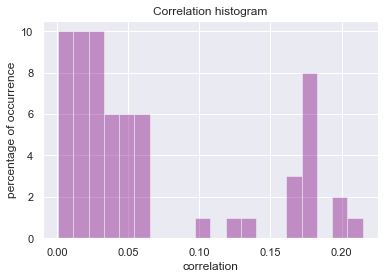

```python
train_cat = data_clean.copy()
correlations = train_cat.corr()["level2"].drop(["level2"]).abs()
sns.set(style="darkgrid")
ax = sns.distplot(correlations.values, kde=False, color="purple",bins=20)
ax.set_title("Correlation histogram")
ax.set_xlabel("correlation")
ax.set_ylabel("percentage of occurrence")
print()
```

```python
# Train/test split
X_train, X_test, y_train, y_test = train_test_split( X, y_labels, test_size=0.1, random_state=0)

# Create validation set
X_train, X_val, y_train, y_val = train_test_split(X_train, y_train, test_size=0.25, random_state=0)
```

```python
sklearn.metrics.SCORERS.keys()
```

```
dict_keys(['explained_variance', 'r2', 'max_error', 'neg_median_absolute_error', 'neg_mean_absolute_error', 'neg_mean_squared_error', 'neg_mean_squared_log_error', 'neg_root_mean_squared_error', 'neg_mean_poisson_deviance', 'neg_mean_gamma_deviance', 'accuracy', 'roc_auc', 'roc_auc_ovr', 'roc_auc_ov…
```

```python
model = RandomForestClassifier(verbose = 0)

scores = cross_val_score(model, X_train, y_train,
                                cv=5,
                                scoring='accuracy',
                                n_jobs=6)
print("Average accuracy score (across experiments): ", scores.mean())
```

```
Average accuracy score (across experiments):  0.8261713746379341
```

```python
parameters = {
    "n_estimators":[50],
    "min_samples_split": np.linspace(0.001, 0.005, 5),
    "min_samples_leaf": np.linspace(0.0005, 0.005, 5),
    "max_depth":[20, 15, 10],
    "max_features":["auto", "log2", "sqrt"],
    "criterion": ["gini",  "entropy"],
    }

grid_search = GridSearchCV(model, parameters, verbose = 1, n_jobs=-1, cv=5)

grid_search.fit(X_train, y_train)
print(grid_search.best_score_)
print(grid_search.best_params_)
```

```
Fitting 5 folds for each of 450 candidates, totalling 2250 fits
```

```
[Parallel(n_jobs=-1)]: Using backend LokyBackend with 12 concurrent workers.
[Parallel(n_jobs=-1)]: Done  26 tasks      | elapsed:  3.1min
[Parallel(n_jobs=-1)]: Done 176 tasks      | elapsed: 13.2min
[Parallel(n_jobs=-1)]: Done 426 tasks      | elapsed: 31.8min
[Parallel(n_jobs=-1)]: Done 776 tasks      | elapsed: 54.7min
[Parallel(n_jobs=-1)]: Done 1226 tasks      | elapsed: 95.6min
[Parallel(n_jobs=-1)]: Done 1776 tasks      | elapsed: 185.6min
[Parallel(n_jobs=-1)]: Done 2250 out of 2250 | elapsed: 264.6min finished
[Parallel(n_jobs=1)]: Using backend SequentialBackend with 1 concurrent workers.
```

```
building tree 1 of 50
```

```
[Parallel(n_jobs=1)]: Done   1 out of   1 | elapsed:    1.7s remaining:    0.0s
```

[output not shown]

```
[Parallel(n_jobs=1)]: Done  50 out of  50 | elapsed:  1.5min finished
```

```python
bestModel = RandomForestClassifier(n_estimators=50,
                                     min_samples_split=0.001,
                                     min_samples_leaf=0.0005,
                                     max_depth=20,
                                     max_features="auto",
                                     criterion="entropy")
bestModel.fit(X_train, y_train)
```

```
RandomForestClassifier(bootstrap=True, ccp_alpha=0.0, class_weight=None,
                       criterion='entropy', max_depth=20, max_features='auto',
                       max_leaf_nodes=None, max_samples=None,
                       min_impurity_decrease=0.0, min_impurity_split=None,
                       min_samples_leaf=0.0005, min_samples_split=0.001,
                       min_weight_fraction_leaf=0.0, n_estimators=50,
                       n_jobs=None, oob_score=False, random_state=None,
                       verbose=0, warm_start=False)
```

```python
print("Accuracy on test set:", accuracy_score(bestModel.predict(X_test), y_test))
```

```
Accuracy on test set: 0.7933720786447385
```

## Logistic regression

```python
pt = PowerTransformer()
pt.fit(X_train)
X_train_normalized = pt.transform(X_train)
```

```python
model = LogisticRegression(verbose = 0)

scores = cross_val_score(model, X_train_normalized, y_train,
                                cv=5,
                                scoring='accuracy',
                                n_jobs=6)
print("Average accuracy score (across experiments): ", scores.mean())
```

```
Average accuracy score (across experiments):  0.7684341002158714
```

```python
parameters = {
    "penalty":['l2'],
    "tol": np.linspace(10**-5, 10**-3, 3),
    "C": np.linspace(1, 2, 3),
    "solver": ["sag", "saga"]
    }

grid_search = GridSearchCV(model, parameters, verbose = 1, n_jobs=6, cv=5)

grid_search.fit(X_train_normalized, y_train)
print(grid_search.best_score_)
print(grid_search.best_params_)
```

```
Fitting 5 folds for each of 18 candidates, totalling 90 fits
```

```
[Parallel(n_jobs=6)]: Using backend LokyBackend with 6 concurrent workers.
[Parallel(n_jobs=6)]: Done  38 tasks      | elapsed: 18.7min
[Parallel(n_jobs=6)]: Done  90 out of  90 | elapsed: 45.6min finished
```

```
0.7804090164007418
{'C': 2.0, 'penalty': 'l2', 'solver': 'sag', 'tol': 1e-05}
```

```python
bestModel = LogisticRegression(penalty = "l2",
                               tol= 10**-5,
                               C = 2,
                               solver="sag",
                               max_iter= 1000)

bestModel.fit(X_train_normalized, y_train)
```

```
LogisticRegression(C=2, class_weight=None, dual=False, fit_intercept=True,
                   intercept_scaling=1, l1_ratio=None, max_iter=1000,
                   multi_class='auto', n_jobs=None, penalty='l2',
                   random_state=None, solver='sag', tol=1e-05, verbose=0,
                   warm_start=False)
```

```python
from sklearn.metrics import f1_score

X_test_norm = pt.transform(X_test)

def accuracy(y, y_hat):
    return (y == y_hat).sum() / y.size

y_pred = bestModel.predict(X_test_norm)

print("weighted", f1_score(y_test, y_pred, average='weighted'))
print("macro", f1_score(y_test, y_pred, average='macro'))
print("accuracy", accuracy(y_pred, y_test))
```

```
weighted 0.7605072952744129
macro 0.3503138089257003
accuracy 0.7794402539054449
```

```python
X_test_norm = pt.transform(X_test)

print("Accuracy on train set:", accuracy_score(bestModel.predict(X_train_normalized), y_train))

print("Accuracy on test set:", accuracy_score(bestModel.predict(X_test_norm), y_test))
```

```
Accuracy on train set: 0.7841828540721426
Accuracy on test set: 0.7794402539054449
```

## Neural net try

```python
pt = PowerTransformer()
pt.fit(X_train)
X_train = pt.transform(X_train)
```

```python
class DataGenerator(Sequence):
    def __init__(self, X, y, minibatch_size, n_classes):
        self.X = X
        self.y = y
        self.minibatch_size = min(minibatch_size, len(self.X))
        self.n_classes = n_classes

    def __len__(self):
        'Denotes the number of batches per epoch'
        return int(self.y.size / self.minibatch_size)

    def on_epoch_end(self):
        'Updates indexes after each epoch'
        # Assuming it preserves the correlation between labels and picture ids
        shuffle = np.random.permutation(len(self.X))
        self.X = self.X[shuffle]
        self.y = self.y[shuffle]

    def __getitem__(self, index):
        Xbatch = self.X[index * self.minibatch_size : (index + 1 )* self.minibatch_size]
        ybatch = self.y[index * self.minibatch_size : (index + 1 )* self.minibatch_size]
        return Xbatch, to_categorical(ybatch.reshape((-1, 1)), num_classes=self.n_classes)
```

```python
training_generator = DataGenerator(X=X_train, y=y_train, minibatch_size=20, n_classes=39)
validation_generator = DataGenerator(X=X_val, y=y_val, minibatch_size=20, n_classes=39)
```

```python
#create model
model = Sequential()
model.add(Dense(80, input_shape=(64,), activation="relu"))
model.add(Dense(num_classes, activation='softmax'))

model.summary()
```

```
Model: "sequential_4"
_________________________________________________________________
Layer (type)                 Output Shape              Param #
=================================================================
dense_10 (Dense)             (None, 80)                5200
_________________________________________________________________
dense_11 (Dense)             (None, 39)                3159
=================================================================
Total params: 8,359
Trainable params: 8,359
Non-trainable params: 0
_________________________________________________________________
```

```python
model.compile(optimizer='adam', loss='categorical_crossentropy', metrics=['accuracy'])

#Keep track of the training time
start = time.time()

# Train model on dataset
model.fit_generator(generator=training_generator,
                    validation_data=validation_generator,
                    epochs=3,
                    use_multiprocessing=False,
                    workers=1)

#model.fit(X_train, y_train, validation_data=(X_val, y_val), epochs=3)
end = time.time()
hours, rem = divmod(end-start, 3600)
minutes, seconds = divmod(rem, 60)
print("Training time :")
print("{:0>2}:{:0>2}:{:05.2f}".format(int(hours),int(minutes),seconds))
```

```
Training time :
00:00:40.44
```

# CNN approach

## Imports

```python
import numpy as np
import seaborn as sns
import matplotlib.pyplot as plt
import pandas as pd

from collections import Counter

from sklearn.model_selection import train_test_split, GridSearchCV, StratifiedShuffleSplit
from sklearn import preprocessing
from sklearn.metrics import f1_score
from skimage.transform import rescale, resize
from sklearn.metrics import confusion_matrix
import seaborn as sns

import tensorflow as tf
from tensorflow.keras.models import Sequential
from tensorflow.keras.layers import Dense, Conv2D, Flatten, Lambda, Reshape, MaxPooling2D, BatchNormalization, Activation
from tensorflow.keras.utils import Sequence, to_categorical
from tensorflow.keras.preprocessing.image import ImageDataGenerator
from tensorflow.keras.applications.vgg16 import VGG16, preprocess_input

import zipfile
from io import BytesIO
from PIL import Image
import time
import warnings

def warn(*args, **kwargs):
    pass
warnings.warn = warn
warnings.filterwarnings("ignore")
warnings.simplefilter('ignore')
```

```python
def extract_zip_to_memory(input_zip):
    '''
    This function extracts the images stored inside the given zip file.
    It stores the result in a python dictionary.

    input_zip (string): path to the zip file

    returns (dict): {filename (string): image_file (bytes)}
    '''
    input_zip = zipfile.ZipFile(input_zip)
    return {name: BytesIO(input_zip.read(name)) for name in input_zip.namelist() if name.endswith('.jpg')}
```

```python
root_directory = '/mnt/datasets/plankton/flowcam/'
img_files = extract_zip_to_memory(root_directory + 'imgs.zip')
```

## Data visualization

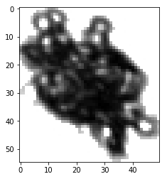

```python
# Display an example image
Image.open(img_files['imgs/32738710.jpg'])

# Load the image as a numpy array:
img_32738710 = np.array(Image.open(img_files['imgs/32738710.jpg']))

plt.imshow(img_32738710, cmap='gray')

# Be aware that the dictionary will occupy roughly 2GB of computer memory!
# To free this memory again, run:
# del img_files
```

```python
meta_data = pd.read_csv(root_directory + 'meta.csv')
taxo_data = pd.read_csv(root_directory + 'taxo.csv')
list_taxo_data = np.array(taxo_data['levelName'])
```

Let's explore null values

```python
meta_data.info()
```

```
<class 'pandas.core.frame.DataFrame'>
RangeIndex: 243610 entries, 0 to 243609
Data columns (total 14 columns):
objid          243610 non-null float64
projid         243610 non-null int64
id             243610 non-null int64
status         243610 non-null object
latitude       243610 non-null float64
longitude      243610 non-null float64
objdate        243610 non-null object
objtime        243610 non-null object
depth_min      243610 non-null int64
depth_max      243610 non-null int64
unique_name    243610 non-null object
lineage        243610 non-null object
level1         240276 non-null object
level2         242607 non-null object
dtypes: float64(3), int64(4), object(7)
memory usage: 26.0+ MB
```

242607 values out of 243610 entries in level 2 are not null. We will drop the null values since they are absolutely necessary.

```python
meta_data_cleaned = meta_data.dropna(subset=['level2'])
```

Let's have a look at the different classes in level 2:

```python
classes = meta_data_cleaned['level2'].unique()
num_classes = len(classes)
classes_ids = {k: v for v, k in enumerate(classes)}
print(classes_ids)
print("Number of classes: "+str(num_classes))
```

```
{'Ceratocorys horrida': 14, 'Annelida': 13, 'tempChaetoceros danicus': 37, 'Undellidae': 18, 'feces': 3, 'artefact': 27, 'Thalassionema': 17, 'Lithodesmioides': 36, 'Retaria': 23, 'detritus': 0, 'pollen': 22, 'chainlarge': 26, 'Asterionellopsis': 5, 'multiple (other)': 24, 'Pleurosigma': 28, 'Protop…
Number of classes: 39
```

Let's have a look at the dimensions of our images:

```python
# Long loading time for this cell (3 min)

dimensions = [] # How many chanels do we have?
shapes = []  # Does all of the images have the same shape?
for objid in meta_data_cleaned['objid'].values:
    path = 'imgs/'+ str(int(objid)) +'.jpg'
    img = np.array(Image.open(img_files[path]))
    shape = img.shape
    if shape not in shapes:
        shapes.append(shape)
    dim = len(shape)
    if dim not in dimensions:
        dimensions.append(dim)


print("Number of dimensions: "+ str(dimensions))
print("Number of different images shapes: " + str(len(shapes)))
```

```
Number of dimensions: [2]
Number of different images shapes: 53074
```

We can see that we will have some data preprocessing to conduct / specific way to load data, as there are many different shapes, and that all of the inputs of a CNN have to be of the same shape. Also, we can see that the pictures are in 2D, therefore there is only one grey channel.

## Data loading

### Creating the train, validation, test sets

We will create these datasets referencing picture ids and they won't contains the images themself.

```python
# X ids

X_ids = np.array(meta_data_cleaned.objid[:].apply(lambda x: str(x).split(".")[0]))
print(X_ids[:5])
print(len(X_ids))
```

```
['32756761' '32759364' '32758055' '32758988' '32760598']
242607
```

```python
# y

y_labels = np.array([classes_ids[level2] for level2 in meta_data_cleaned.level2.values])
print(y_labels[:5])
print(len(y_labels))
```

```
[0 0 1 2 2]
242607
```

#### Let's create our train, validation and test sets:

```python
# Train/test split
sss = StratifiedShuffleSplit(n_splits=1, train_size=0.5, random_state=0)
train_index, test_index = next(sss.split(X_ids, y_labels))
X_train, X_test = X_ids[train_index], X_ids[test_index]
y_train, y_test = y_labels[train_index], y_labels[test_index]

# Create validation set
sss = StratifiedShuffleSplit(n_splits=1, train_size=0.75, random_state=0)
train_index, val_index = next(sss.split(X_train, y_train))
X_train, X_val = X_train[train_index], X_train[val_index]
y_train, y_val = y_train[train_index], y_train[val_index]
```

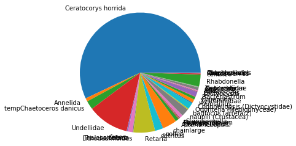

```python
plt.pie(np.unique(np.array(y_train), return_counts=True)[1], labels=[k for k in classes_ids],
           autopct=None)
plt.axis("equal")
plt.show()
```

## Data generator

We need to load our pictures "on the fly", in a more efficient way: we want real-time data feeding of our Keras model. For the data generator, we got inspired by this website : https://stanford.edu/~shervine/blog/keras-how-to-generate-data-on-the-fly

```
(148, 65)
```

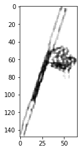

```
(100, 100)
```

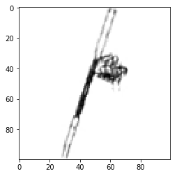

```python
# Helper functions to access an image of the dataset
def resizeImage(img, w=100, l=100):
    w_, l_ = img.shape
    scale_factor = min(float(w)/float(w_), float(l)/float(l_))
    img = rescale(img, scale_factor, anti_aliasing=True, mode='reflect', multichannel=False)
    Dw, Dl = w - img.shape[0], l - img.shape[1]
    img = np.pad(img, ((int(np.ceil(Dw/2)), int(np.floor(Dw/2))),(int(np.ceil(Dl/2)), int(np.floor(Dl/2)))), mode='constant', constant_values=1.)
    return img


def accessImage(img_id, w=100, l=100): # Allows us to access the "resized" image
    img = np.array(Image.open(img_files['imgs/'+str(img_id)+'.jpg']))
    return resizeImage(img, w, l).reshape(w, l, 1)

img = np.array(Image.open(img_files['imgs/32758047.jpg']))
print(img.shape)
plt.imshow(img, cmap='gray')
plt.show()
img = resizeImage(img)
print(img.shape)
plt.imshow(img, cmap='gray')
plt.show()
```

```python
class DataGenerator(Sequence):
    'Generates data for Keras'
    def __init__(self, ids, labels, batch_size=32, dim=(100,100), n_channels=1,
                 n_classes=num_classes, shuffle=False, data_augmentation=False):
        'Initialization'
        self.dim = dim
        self.batch_size = batch_size
        self.labels = labels[:]
        self.list_IDs = ids[:]
        self.n_channels = n_channels
        self.n_classes = n_classes
        self.shuffle = shuffle
        self.on_epoch_end()
        self.data_augmentation = data_augmentation
        if self.data_augmentation:
            self.datagen = ImageDataGenerator(
                rotation_range=180,
                width_shift_range=0.1,
                height_shift_range=0.1,
                horizontal_flip=True,
                vertical_flip=True,
                fill_mode='nearest')

    def __len__(self):
        'Denotes the number of batches per epoch'
        return int(np.floor(len(self.list_IDs) / self.batch_size))

    def on_epoch_end(self):
        'Updates indexes after each epoch'
        # Assuming it preserves the correlation between labels and picture ids
        self.indexes = np.arange(len(self.list_IDs))
        if self.shuffle == True:
            np.random.shuffle(self.indexes)

    def __getitem__(self, index):
        'Generate one batch of data'
        # Generate indexes of the batch
        indexes = self.indexes[index*self.batch_size:(index+1)*self.batch_size]

        # Find list of IDs
        list_IDs_temp = [self.list_IDs[k] for k in indexes]

        # Generate data
        X, y = self.__data_generation(indexes, list_IDs_temp)

        return X, y

    def __data_generation(self, indexes, list_IDs_temp):
        'Generates data containing batch_size samples'
        # Initialization
        # X : (n_samples, *dim, n_channels)
        X = np.empty((len(indexes), *self.dim, self.n_channels))
        y = np.empty((len(indexes),1), dtype=int)

        if self.data_augmentation:
            X, y = next(self.datagen.flow(X, y, batch_size=self.batch_size, shuffle=False))

        # Generate data
        for i in range(len(indexes)):
            # Store sample
            ID = list_IDs_temp[i]
            X[i,] = accessImage(ID, self.dim[0], self.dim[1])
            # Store class
            y[i] = self.labels[indexes[i]]

        # return X, y
        return X, to_categorical(y, num_classes=self.n_classes)
```

(If we want to put text on the final presentation and not code)

**Initialisation**: We put as arguments relevant information about the data, such as dimension sizes, number of channels, number of classes, batch size, or decide whether we want to shuffle our data at generation. We also store important information such as labels and the list of IDs that we wish to generate at each pass.

**On epoch end**: Here, the method on_epoch_end is triggered once at the very beginning as well as at the end of each epoch. If the shuffle parameter is set to True, we will get a new order of exploration at each pass (or just keep a linear exploration scheme otherwise).

**len**: Each call requests a batch index between 0 and the total number of batches, where the latter is specified in the len method. A common practice to set this value is to ensure that the model sees the training samples at most once per epoch.

**getitem**: to generate the batch corresponding to a given index

## Model Selection

Let's design our model :

Used with adam optimizer, the loss is categorical crossentropy. Metric is accuracy.

```python
# Parameters
params = {'dim': (100, 100),
          'input_shape' :(100, 100, 1),
          'train_batch_size': 64,
          'val_batch_size': 32,
          'shuffle': True}

# Generators
training_generator = DataGenerator(ids=X_train, labels=y_train, batch_size=params['train_batch_size'], dim=params['dim'], n_channels=1,
                 n_classes=num_classes, shuffle=True, data_augmentation=True)
validation_generator = DataGenerator(ids=X_val, labels=y_val, batch_size=params['val_batch_size'], dim=params['dim'], n_channels=1,
                 n_classes=num_classes, shuffle=True)
```

```python
def train(model, epochs=6):
    #Keep track of the training time
    start = time.time()

    # Train model on dataset
    model.fit(training_generator,
              validation_data=validation_generator,
              epochs=epochs,
              use_multiprocessing=False,
              workers=1)

    #model.fit(X_train, y_train, validation_data=(X_val, y_val), epochs=3)
    end = time.time()
    hours, rem = divmod(end-start, 3600)
    minutes, seconds = divmod(rem, 60)
    print("Training time :")
    print("{:0>2}:{:0>2}:{:05.2f}".format(int(hours), int(minutes), seconds))
```

```python
unnomalized_weights = 1/(np.log(np.unique(np.array(y_labels), return_counts=True)[1].astype(np.float32)) + 0.01)
weights = tf.constant(unnomalized_weights/unnomalized_weights.sum())

def weighted_categorical_crossentropy(target, output, axis=-1):
    # scale preds so that the class probas of each sample sum to 1
    output = output / tf.math.reduce_sum(output, axis, True)
    # Compute cross entropy from probabilities.
    epsilon_ = tf.keras.backend.epsilon()
    output = tf.clip_by_value(output, epsilon_, 1. - epsilon_)
    return -tf.reduce_mean(tf.math.reduce_sum(weights * (target * tf.math.log(output) + (1 - target) * tf.math.log(1-output)), axis))
```

```python
model = Sequential()
model.add(Conv2D(8, kernel_size=4, activation='relu', input_shape = params['input_shape']))
model.add(MaxPooling2D(pool_size=(2, 2), strides=(2, 2), padding='valid'))
model.add(Conv2D(16, kernel_size=3, activation='relu'))
model.add(MaxPooling2D(pool_size=(2, 2), strides=(2, 2), padding='valid'))
model.add(Conv2D(32, kernel_size=2, activation='relu'))
model.add(MaxPooling2D(pool_size=(2, 2), strides=(2, 2), padding='valid'))
model.add(Conv2D(64, kernel_size=2, activation='relu'))
model.add(MaxPooling2D(pool_size=(2, 2), strides=(2, 2), padding='valid'))
model.add(Conv2D(128, kernel_size=2, activation='relu'))
model.add(MaxPooling2D(pool_size=(2, 2), strides=(2, 2), padding='valid'))
model.add(Flatten())
model.add(Dense(num_classes, activation='sigmoid'))

model.compile(optimizer='adam', loss=weighted_categorical_crossentropy, metrics=['accuracy'])

model.summary()
```

```
Model: "sequential_1"
_________________________________________________________________
Layer (type)                 Output Shape              Param #
=================================================================
conv2d_4 (Conv2D)            (None, 97, 97, 8)         136
_________________________________________________________________
max_pooling2d_3 (MaxPooling2 (None, 48, 48, 8)         0
_________________________________________________________________
conv2d_5 (Conv2D)            (None, 46, 46, 16)        1168
_________________________________________________________________
max_pooling2d_4 (MaxPooling2 (None, 23, 23, 16)        0
_________________________________________________________________
conv2d_6 (Conv2D)            (None, 22, 22, 32)        2080
_________________________________________________________________
max_pooling2d_5 (MaxPooling2 (None, 11, 11, 32)        0
_________________________________________________________________
conv2d_7 (Conv2D)            (None, 10, 10, 64)        8256
_________________________________________________________________
max_pooling2d_6 (MaxPooling2 (None, 5, 5, 64)          0
_________________________________________________________________
conv2d_8 (Conv2D)            (None, 4, 4, 128)         32896
_________________________________________________________________
max_pooling2d_7 (MaxPooling2 (None, 2, 2, 128)         0
_________________________________________________________________
flatten_1 (Flatten)          (None, 512)               0
_________________________________________________________________
dense_2 (Dense)              (None, 39)                20007
=================================================================
Total params: 64,543
Trainable params: 64,543
Non-trainable params: 0
_________________________________________________________________
```

```python
train(model, epochs=1)
model.save_weights('models/model/model')
```

```
WARNING:tensorflow:multiprocessing can interact badly with TensorFlow, causing nondeterministic deadlocks. For high performance data pipelines tf.data is recommended.
WARNING:tensorflow:multiprocessing can interact badly with TensorFlow, causing nondeterministic deadlocks. For high performance data pipelines tf.data is recommended.
Training time :
00:09:32.87
```

```python
model1 = Sequential()
model1.add(Conv2D(16, kernel_size=6, activation='relu', input_shape = params['input_shape']))
model1.add(MaxPooling2D(pool_size=(3, 3), strides=(3, 3), padding='valid'))
model1.add(Conv2D(24, kernel_size=5, activation='relu'))
model1.add(MaxPooling2D(pool_size=(2, 2), strides=(2, 2), padding='valid'))
model1.add(Conv2D(32, kernel_size=4, activation='relu'))
model1.add(MaxPooling2D(pool_size=(2, 2), strides=(2, 2), padding='valid'))
model1.add(Conv2D(64, kernel_size=2, activation='relu'))
model1.add(Flatten())
model1.add(Dense(100, activation='relu'))
model1.add(Dense(num_classes, activation='sigmoid'))

model1.compile(optimizer='adam', loss=weighted_categorical_crossentropy, metrics=['accuracy'])

model1.summary()
```

```
Model: "sequential_11"
_________________________________________________________________
Layer (type)                 Output Shape              Param #
=================================================================
conv2d_13 (Conv2D)           (None, 95, 95, 16)        592
_________________________________________________________________
max_pooling2d_3 (MaxPooling2 (None, 31, 31, 16)        0
_________________________________________________________________
conv2d_14 (Conv2D)           (None, 27, 27, 24)        9624
_________________________________________________________________
max_pooling2d_4 (MaxPooling2 (None, 13, 13, 24)        0
_________________________________________________________________
conv2d_15 (Conv2D)           (None, 10, 10, 32)        12320
_________________________________________________________________
max_pooling2d_5 (MaxPooling2 (None, 5, 5, 32)          0
_________________________________________________________________
conv2d_16 (Conv2D)           (None, 4, 4, 64)          8256
_________________________________________________________________
flatten_8 (Flatten)          (None, 1024)              0
_________________________________________________________________
dense_15 (Dense)             (None, 100)               102500
_________________________________________________________________
dense_16 (Dense)             (None, 39)                3939
=================================================================
Total params: 137,231
Trainable params: 137,231
Non-trainable params: 0
_________________________________________________________________
```

```python
train(model1, epochs=5)
model1.save_weights('models/model1_dataaug/model1_dataaug')
```

```
Training time :
00:34:11.41
```

```python
model2 = Sequential()
model2.add(Conv2D(16, kernel_size=6, input_shape = params['input_shape']))
model2.add(BatchNormalization(momentum=0.8))
model2.add(Activation('tanh'))
model2.add(MaxPooling2D(pool_size=(3, 3), strides=(3, 3), padding='valid'))
model2.add(Conv2D(24, kernel_size=5))
model2.add(BatchNormalization(momentum=0.8))
model2.add(Activation('tanh'))
model2.add(MaxPooling2D(pool_size=(2, 2), strides=(2, 2), padding='valid'))
model2.add(Conv2D(32, kernel_size=4))
model2.add(BatchNormalization(momentum=0.8))
model2.add(Activation('tanh'))
model2.add(MaxPooling2D(pool_size=(2, 2), strides=(2, 2), padding='valid'))
model2.add(Conv2D(64, kernel_size=2))
model2.add(BatchNormalization(momentum=0.8))
model2.add(Activation('tanh'))
model2.add(Flatten())
model2.add(Dense(100, activation='relu'))
model2.add(Dense(num_classes, activation='sigmoid'))

model2.compile(optimizer='adam', loss=weighted_categorical_crossentropy, metrics=['accuracy'])

model2.summary()
```

```
Model: "sequential_1"
_________________________________________________________________
Layer (type)                 Output Shape              Param #
=================================================================
conv2d_1 (Conv2D)            (None, 95, 95, 16)        592
_________________________________________________________________
batch_normalization_1 (Batch (None, 95, 95, 16)        64
_________________________________________________________________
activation (Activation)      (None, 95, 95, 16)        0
_________________________________________________________________
max_pooling2d (MaxPooling2D) (None, 31, 31, 16)        0
_________________________________________________________________
conv2d_2 (Conv2D)            (None, 27, 27, 24)        9624
_________________________________________________________________
batch_normalization_2 (Batch (None, 27, 27, 24)        96
_________________________________________________________________
activation_1 (Activation)    (None, 27, 27, 24)        0
_________________________________________________________________
max_pooling2d_1 (MaxPooling2 (None, 13, 13, 24)        0
_________________________________________________________________
conv2d_3 (Conv2D)            (None, 10, 10, 32)        12320
_________________________________________________________________
batch_normalization_3 (Batch (None, 10, 10, 32)        128
_________________________________________________________________
activation_2 (Activation)    (None, 10, 10, 32)        0
_________________________________________________________________
max_pooling2d_2 (MaxPooling2 (None, 5, 5, 32)          0
_________________________________________________________________
conv2d_4 (Conv2D)            (None, 4, 4, 64)          8256
_________________________________________________________________
batch_normalization_4 (Batch (None, 4, 4, 64)          256
_________________________________________________________________
activation_3 (Activation)    (None, 4, 4, 64)          0
_________________________________________________________________
flatten (Flatten)            (None, 1024)              0
_________________________________________________________________
dense (Dense)                (None, 100)               102500
_________________________________________________________________
dense_1 (Dense)              (None, 39)                3939
=================================================================
Total params: 137,775
Trainable params: 137,503
Non-trainable params: 272
_________________________________________________________________
```

```python
train(model2, epochs=10)
model2.save_weights('models/model2/model2')
```

[output not shown]

[output not shown]

## Backbone

```python
vgg16 = VGG16(include_top=False, weights='imagenet', input_shape=(99, 99, 3), pooling='max')
for layer in vgg16.layers:
    layer.trainable = False
model_backbone = Sequential()
model_backbone.add(Conv2D(3, kernel_size=2, input_shape = params['input_shape']))
model_backbone.add(vgg16)
model_backbone.add(Flatten())
model_backbone.add(Dense(100, activation='relu'))
model_backbone.add(Dense(num_classes, activation='sigmoid'))
model_backbone.compile(optimizer='adam', loss=weighted_categorical_crossentropy, metrics=['accuracy'])

model_backbone.summary()
```

```
Model: "sequential_10"
_________________________________________________________________
Layer (type)                 Output Shape              Param #
=================================================================
conv2d_12 (Conv2D)           (None, 99, 99, 3)         15
_________________________________________________________________
vgg16 (Model)                (None, 512)               14714688
_________________________________________________________________
flatten_7 (Flatten)          (None, 512)               0
_________________________________________________________________
dense_13 (Dense)             (None, 100)               51300
_________________________________________________________________
dense_14 (Dense)             (None, 39)                3939
=================================================================
Total params: 14,769,942
Trainable params: 55,254
Non-trainable params: 14,714,688
_________________________________________________________________
```

```python
train(model_backbone, epochs=5)
model_backbone.save_weights('models/model_backbone/model_backbone')
```

```
WARNING:tensorflow:multiprocessing can interact badly with TensorFlow, causing nondeterministic deadlocks. For high performance data pipelines tf.data is recommended.
```

[output not shown]

[output not shown]

[output not shown]

[output cut: 22 more lines]

[output not shown]

### Performance Evaluation

```python
model.load_weights("models/model/model")
model1.load_weights("models/model1/model1")
model2.load_weights("models/model2/model2")
```

```
<tensorflow.python.training.tracking.util.CheckpointLoadStatus at 0x7f9bc9806a58>
```

```python
testing_generator = DataGenerator(ids=X_test, labels=y_test, batch_size=32, dim=params['dim'], n_channels=1, n_classes=num_classes)
predictions = model1.predict(testing_generator, verbose=1, workers=8, use_multiprocessing=True)
```

```
WARNING:tensorflow:multiprocessing can interact badly with TensorFlow, causing nondeterministic deadlocks. For high performance data pipelines tf.data is recommended.
```

```python
print(predictions[0])
print(len(predictions[0]))
```

[output not shown]

```python
y_pred = np.argmax(predictions, axis=1)


def accuracy(y, y_hat):
    return (y == y_hat).sum() / y.size

print(f1_score(y_test[:len(y_pred)], y_pred, average='weighted'))
accuracy(y_pred, y_test[:len(y_pred)])
```

```
0.7570115610288449
```

```
0.7743238786279684
```

macro: Calculate metrics for each label, and find their unweighted mean. This does not take label imbalance into account.

```python
print(np.unique(y_test, return_counts=True)[1])
print(np.unique(y_pred, return_counts=True)[1])
```

```
[69220  1080  2815 13468   423    58  1444   274  7007  2571   167  4647
  1128   240    93   262  1053  2559   355  2022   335  1114   911   128
  1631   183   376   925    95    65    72    50  3924   343   178    18
    34    30     6]
[80106   695  3126  9943   274  1400   141  5974  2220    92  5431   744
    43    15   543  2161   125  1396   198   536   956    42   469    14
   194   573    31    19     1  3659   156     3]
```

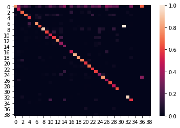

```python
cm = confusion_matrix(y_test[:len(y_pred)], y_pred, normalize='pred')
sns.heatmap(cm)
```

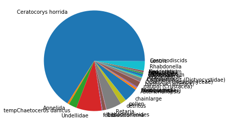

```python
# data aug w 0.01
plt.pie(np.unique(np.array(y_pred), return_counts=True)[1], labels=np.array([k for k in classes_ids])[np.unique(np.array(y_pred), return_counts=True)[0]],
           autopct=None)
plt.axis("equal")
plt.show()
```

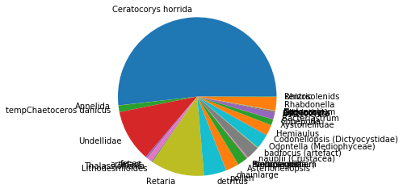

```python
# batchnorm
plt.pie(np.unique(np.array(y_pred), return_counts=True)[1], labels=np.array([k for k in classes_ids])[np.unique(np.array(y_pred), return_counts=True)[0]],
           autopct=None)
plt.axis("equal")
plt.show()
```

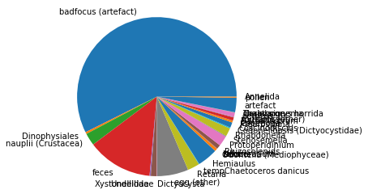

```python
# no data aug + w 0.01
plt.pie(np.unique(np.array(y_pred), return_counts=True)[1], labels=np.array([k for k in classes_ids])[np.unique(np.array(y_pred), return_counts=True)[0]],
           autopct=None)
plt.axis("equal")
plt.show()
```

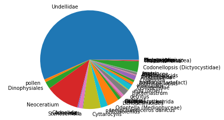

```python
plt.pie(np.unique(np.array(y_test), return_counts=True)[1], labels=[k for k in classes_ids],
           autopct=None)
plt.axis("equal")
plt.show()
```